# Final Group project

Paola Pavon, Maria Meneses, Yesenia Silva

2025-06-15

# 1 The problem: predicting credit card fraud

The goal of the project is to predict fraudulent credit card transactions.

## 1.1 Obtain the data

Transforming our output variable to a reordered factor is the first step.

```
## Rows: 671,028
## Columns: 14
## $ trans_date_trans_time <dttm> 2019-02-22 07:32:58, 2019-02-16 15:07:20, 2019-…
## $ trans_year            <dbl> 2019, 2019, 2019, 2019, 2019, 2019, 2019, 2020, …
## $ category              <chr> "entertainment", "kids_pets", "personal_care", "…
## $ amt                   <dbl> 7.79, 3.89, 8.43, 40.00, 54.04, 95.61, 64.95, 3.…
## $ city                  <chr> "Veedersburg", "Holloway", "Arnold", "Apison", "…
## $ state                 <chr> "IN", "OH", "MO", "TN", "CO", "GA", "MN", "AL", …
## $ lat                   <dbl> 40.1186, 40.0113, 38.4305, 35.0149, 39.4584, 32.…
## $ long                  <dbl> -87.2602, -80.9701, -90.3870, -85.0164, -106.385…
## $ city_pop              <dbl> 4049, 128, 35439, 3730, 277, 1841, 136, 190178, …
## $ job                   <chr> "Development worker, community", "Child psychoth…
## $ dob                   <date> 1959-10-19, 1946-04-03, 1985-03-31, 1991-01-28,…
## $ merch_lat             <dbl> 39.41679, 39.74585, 37.73078, 34.53277, 39.95244…
## $ merch_long            <dbl> -87.52619, -81.52477, -91.36875, -84.10676, -106…
## $ is_fraud              <fct> 0, 0, 0, 0, 0, 0, 0, 0, 0, 0, 0, 0, 0, 0, 0, 0, …
```

The data dictionary is as follows

| column(variable) | description |
| --- | --- |
| trans_date_trans_time | Transaction DateTime |
| trans_year | Transaction year |
| category | category of merchant |
| amt | amount of transaction |
| city | City of card holder |
| state | State of card holder |
| lat | Latitude location of purchase |
| long | Longitude location of purchase |
| city_pop | card holder’s city population |
| job | job of card holder |
| dob | date of birth of card holder |
| merch_lat | Latitude Location of Merchant |
| merch_long | Longitude Location of Merchant |
| is_fraud | Whether Transaction is Fraud (1) or Not (0) |

We also add some of the variables we considered in our EDA for this dataset during homework 2.

```r
card_fraud <- card_fraud %>%
  mutate( hour = hour(trans_date_trans_time),
          wday = wday(trans_date_trans_time, label = TRUE),
          month_name = month(trans_date_trans_time, label = TRUE),
          age = interval(dob, trans_date_trans_time) / years(1)
) %>%
  rename(year = trans_year) %>%

  mutate(

    # convert latitude/longitude to radians
    lat1_radians = lat / 57.29577951,
    lat2_radians = merch_lat / 57.29577951,
    long1_radians = long / 57.29577951,
    long2_radians = merch_long / 57.29577951,

    # calculate distance in miles
    distance_miles = 3963.0 * acos((sin(lat1_radians) * sin(lat2_radians)) + cos(lat1_radians) * cos(lat2_radians) * cos(long2_radians - long1_radians)),

    # calculate distance in km
    distance_km = 6377.830272 * acos((sin(lat1_radians) * sin(lat2_radians)) + cos(lat1_radians) * cos(lat2_radians) * cos(long2_radians - long1_radians))

  )
```

## 1.2 Exploratory Data Analysis (EDA)

First of all, we group all variables by type and examine each variable class by class. The dataset has the following types of variables:

**1. Strings:** category city state job

**Factors:** is_fraud

**Ordered:** wday month_name

**2. Geospatial Data:** lat long merch_lat merch_long

lat1_radians lat2_radians long1_radians long2_radians

**3. Dates:** dob

**4. Date/Times:** trans_date_trans_time

**5. Numerical:** year amt city_pop hour age distance_miles distance_km

*Strings to Factors* Strings are usually not a useful format for classification problems. The strings should be converted to factors, dropped, or otherwise transformed.

The predictors `category` and `job` are transformed into factors.

```r
card_fraud <- card_fraud %>%
  mutate(category = factor(category),
         job = factor(job))
```

## 1.3 Exploring factors: how is the compactness of categories?

- Do we have excessive number of categories? Do we want to combine some?

```r
card_fraud %>%
  count(category, sort=TRUE)%>%
  mutate(perc = n/sum(n))
```

```
## # A tibble: 14 × 3
##    category           n   perc
##    <fct>          <int>  <dbl>
##  1 gas_transport  68046 0.101
##  2 grocery_pos    63791 0.0951
##  3 home           63597 0.0948
##  4 shopping_pos   60416 0.0900
##  5 kids_pets      58772 0.0876
##  6 shopping_net   50743 0.0756
##  7 entertainment  48521 0.0723
##  8 food_dining    47527 0.0708
##  9 personal_care  46843 0.0698
## 10 health_fitness 44341 0.0661
## 11 misc_pos       41244 0.0615
## 12 misc_net       32829 0.0489
## 13 grocery_net    23485 0.0350
## 14 travel         20873 0.0311
```

```r
card_fraud %>%
  count(job, sort=TRUE) %>%
  mutate(perc = n/sum(n))
```

```
## # A tibble: 494 × 3
##    job                            n    perc
##    <fct>                      <int>   <dbl>
##  1 Film/video editor           5106 0.00761
##  2 Exhibition designer         4728 0.00705
##  3 Naval architect             4546 0.00677
##  4 Surveyor, land/geomatics    4448 0.00663
##  5 Materials engineer          4292 0.00640
##  6 Designer, ceramics/pottery  4262 0.00635
##  7 IT trainer                  4014 0.00598
##  8 Financial adviser           3959 0.00590
##  9 Systems developer           3948 0.00588
## 10 Environmental consultant    3831 0.00571
## # ℹ 484 more rows
```

`category` has 14 unique values, and `job` has 494 unique values. The dataset is quite large, with over 670K records, so these variables don’t have an excessive number of levels at first glance. However, it is worth seeing if we can compact the levels to a smaller number.

## 1.4 Do all variables have sensible types?

Consider each variable and decide whether to keep, transform, or drop it.

## 1.5 STRINGS

### 1.5.1 Exploring category

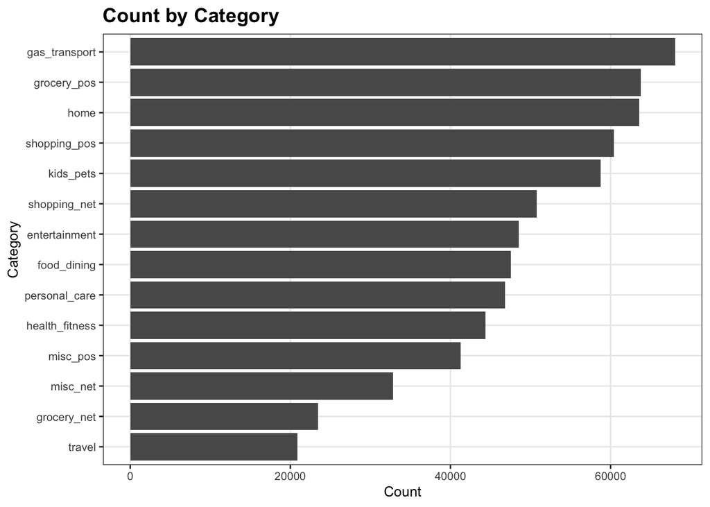

```r
# Count by category
card_fraud %>%
  count(category) %>%
  ggplot(aes(x = reorder(category, n), y = n)) +
  geom_col() +
  coord_flip() +
  labs(title = "Count by Category", x = "Category", y = "Count") +
  theme_bw()  +
  theme(
    plot.title     = element_text(size = 14, face = "bold"),
    axis.title.x   = element_text(size = 10),
    axis.title.y   = element_text(size = 10),
    axis.text      = element_text(size = 8),
    panel.grid.minor = element_blank()
  )
```

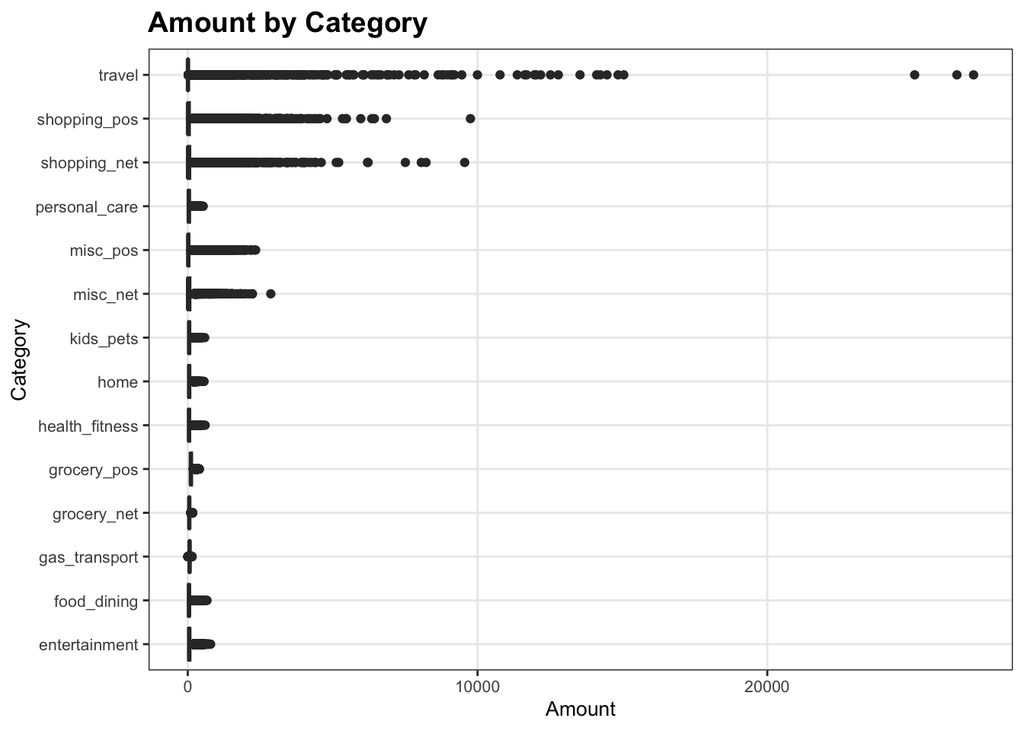

```r
# Amount by Category
ggplot(card_fraud, aes(x = category, y = amt)) +
  geom_boxplot() +
  labs(title = "Amount by Category", x = "Category", y = "Amount") +
  coord_flip() +
   theme_bw()  +
  theme(
    plot.title     = element_text(size = 14, face = "bold"),
    axis.title.x   = element_text(size = 10),
    axis.title.y   = element_text(size = 10),
    axis.text      = element_text(size = 8),
    panel.grid.minor = element_blank()
  )
```

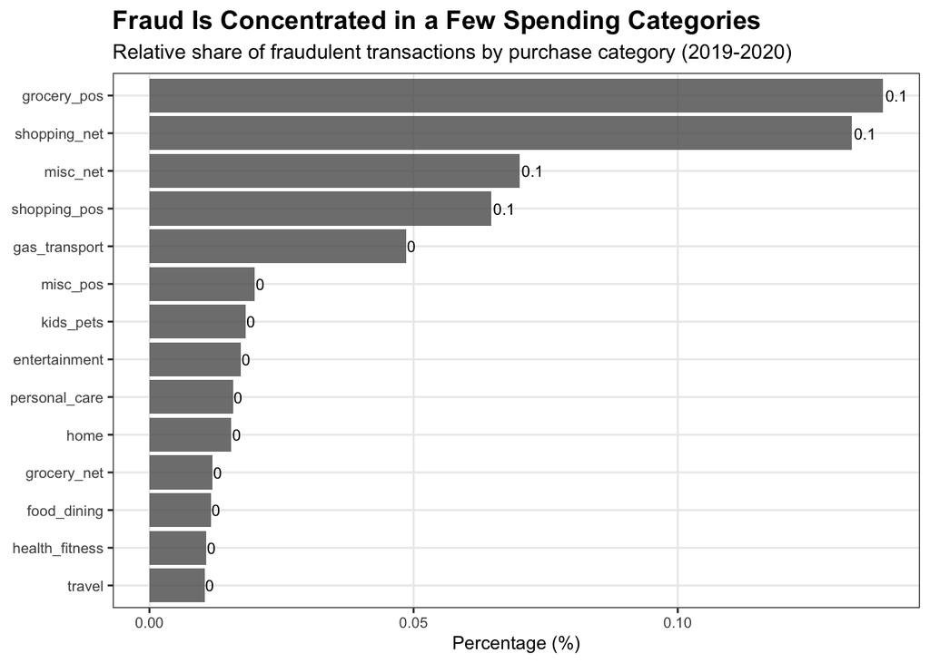

```r
# Category by is_fraud
card_fraud %>%
  group_by(category, is_fraud) %>%
  summarise(count = n(), .groups = "drop") %>%
  mutate(freq = count / sum(count) * 100) %>%
  filter(is_fraud == 1) %>%
  arrange(desc(freq)) %>%
  ggplot(aes(x = reorder(category, freq), y = freq)) +
  geom_bar(stat = "identity", alpha = 0.8) +
  geom_text(aes(label = round(freq, 1)), hjust = -0.1, size = 3) +
  coord_flip() +
  labs(
    title = "Fraud Is Concentrated in a Few Spending Categories",
    subtitle = "Relative share of fraudulent transactions by purchase category (2019-2020)",
    x = NULL,
    y = "Percentage (%)"
  ) +
  theme_bw() +
  theme(
    plot.title     = element_text(size = 14, face = "bold"),
    axis.title.x   = element_text(size = 10),
    axis.title.y   = element_text(size = 10),
    axis.text      = element_text(size = 8),
    panel.grid.minor = element_blank()
  )
```

**CONCLUSION:** The category variable displays a clear imbalance in transaction counts and fraudulent cases across merchant types, with some categories being much more frequent than others. This suggests that merchant category IS a crucial feature, as certain types are more likely to be targeted for fraud. **We will keep this variable in the model.**

### 1.5.2 Exploring city

```r
#---  Fraudulent transactions rate by city   ---#
card_fraud %>%
  group_by(city) %>%
  summarise(
    n_fraud = sum(is_fraud == "1"),
    n_total = n(),
    fraud_rate = n_fraud / n_total
  )  %>%
  arrange(desc(fraud_rate))
```

```
## # A tibble: 894 × 4
##    city        n_fraud n_total fraud_rate
##    <chr>         <int>   <int>      <dbl>
##  1 Angwin            3       3          1
##  2 Ashland           3       3          1
##  3 Beacon            3       3          1
##  4 Brookfield        6       6          1
##  5 Bruce             6       6          1
##  6 Buellton          4       4          1
##  7 Byesville         7       7          1
##  8 Chattanooga       5       5          1
##  9 Clarion           4       4          1
## 10 Claypool          2       2          1
## # ℹ 884 more rows
```

**CONCLUSION:** City is a categorical variable with 894 unique values. These are too many values for it to be useful, considering that most cities have less than 10 fraudulent observations. It is not practical to use city as a predictor in a model, so **we will drop it**.

### 1.5.3 Exploring state

```r
#---  Fraudulent transactions rate by state   ---#
card_fraud %>%
  group_by(state) %>%
  summarise(
    n_fraud = sum(is_fraud == "1"),
    n_total = n(),
    fraud_rate = n_fraud / n_total
  )  %>%
  arrange(desc(fraud_rate))
```

```
## # A tibble: 51 × 4
##    state n_fraud n_total fraud_rate
##    <chr>   <int>   <int>      <dbl>
##  1 DE          7       7    1
##  2 RI          6     273    0.0220
##  3 AK         17    1101    0.0154
##  4 ME         73    8614    0.00847
##  5 NV         24    2918    0.00822
##  6 OR         79    9620    0.00821
##  7 CO         58    7212    0.00804
##  8 TN         71    9092    0.00781
##  9 NE         97   12469    0.00778
## 10 NH         32    4334    0.00738
## # ℹ 41 more rows
```

**CONCLUSION:** Here we have the same logic as with city. State is a categorical variable with 51 unique values. It is not practical to use state as a predictor in a model, so **we will drop it**.

```r
card_fraud %>%
  count(job, sort = TRUE) %>%
  mutate(perc = n * 100 / sum(n)) %>%
  arrange(desc(perc))
```

```
## # A tibble: 494 × 3
##    job                            n  perc
##    <fct>                      <int> <dbl>
##  1 Film/video editor           5106 0.761
##  2 Exhibition designer         4728 0.705
##  3 Naval architect             4546 0.677
##  4 Surveyor, land/geomatics    4448 0.663
##  5 Materials engineer          4292 0.640
##  6 Designer, ceramics/pottery  4262 0.635
##  7 IT trainer                  4014 0.598
##  8 Financial adviser           3959 0.590
##  9 Systems developer           3948 0.588
## 10 Environmental consultant    3831 0.571
## # ℹ 484 more rows
```

```r
card_fraud %>%
  count(job, sort = TRUE) %>%
  mutate(perc = n * 100 / sum(n)) %>%
  summarise(
    min = min(perc),
    max = max(perc),
    mean = mean(perc),
    median = median(perc),
    sd = sd(perc),
    q1 = quantile(perc, 0.25),
    q3 = quantile(perc, 0.75)
  )
```

```
## # A tibble: 1 × 7
##        min   max  mean median    sd     q1    q3
##      <dbl> <dbl> <dbl>  <dbl> <dbl>  <dbl> <dbl>
## 1 0.000298 0.761 0.202  0.163 0.143 0.0827 0.279
```

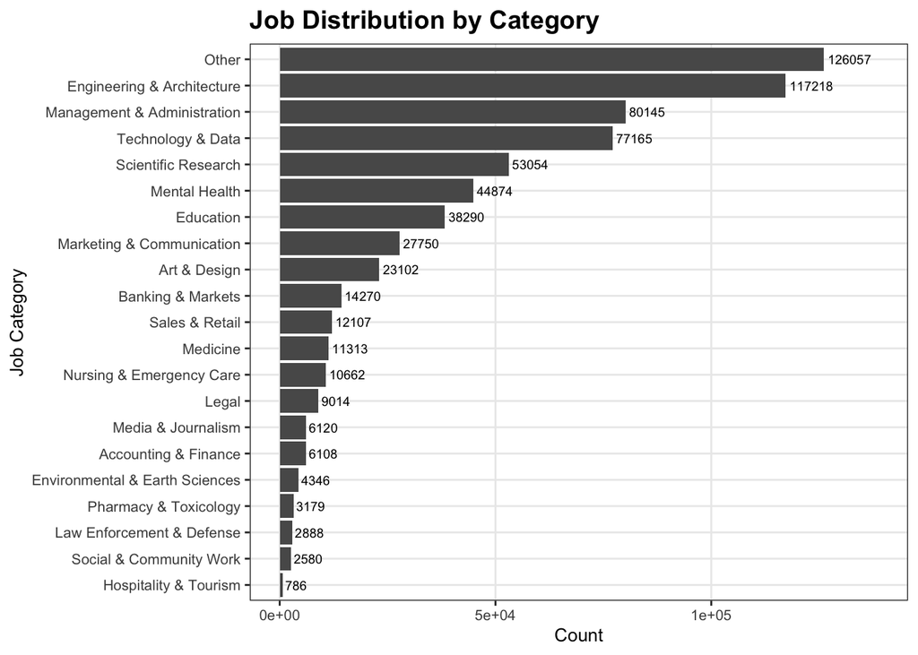

```r
# Classification done by chat gpt
#unique(card_fraud$job)

classified_jobs <- card_fraud %>%
  mutate(job_category_20 = case_when(
    str_detect(job, regex("engineer|engineering|architect|surveyor|planner|technologist", TRUE)) ~ "Engineering & Architecture",
    str_detect(job, regex("doctor|surgeon|oncologist|physician|pathologist", TRUE)) ~ "Medicine",
    str_detect(job, regex("nurse|midwife|paramedic", TRUE)) ~ "Nursing & Emergency Care",
    str_detect(job, regex("therapist|psychologist|counsellor|psychiatrist|psychotherapist", TRUE)) ~ "Mental Health",
    str_detect(job, regex("teacher|lecturer|professor|education|instructor|trainer", TRUE)) ~ "Education",
    str_detect(job, regex("scientist|researcher|biochemist|chemist|geologist|physicist", TRUE)) ~ "Scientific Research",
    str_detect(job, regex("it|developer|programmer|software|data scientist|web|cyber|applications", TRUE)) ~ "Technology & Data",
    str_detect(job, regex("accountant|finance|auditor|bookkeeper", TRUE)) ~ "Accounting & Finance",
    str_detect(job, regex("banker|investment|trader|analyst", TRUE)) ~ "Banking & Markets",
    str_detect(job, regex("manager|coordinator|administrator|officer|director", TRUE)) ~ "Management & Administration",
    str_detect(job, regex("sales|retail|buyer|promotion|merchandiser", TRUE)) ~ "Sales & Retail",
    str_detect(job, regex("marketing|advertising|public relations|pr", TRUE)) ~ "Marketing & Communication",
    str_detect(job, regex("artist|designer|illustrator|animator|art", TRUE)) ~ "Art & Design",
    str_detect(job, regex("media|journalist|broadcast|camera|film|editor", TRUE)) ~ "Media & Journalism",
    str_detect(job, regex("lawyer|solicitor|legal|barrister|attorney", TRUE)) ~ "Legal",
    str_detect(job, regex("police|firefighter|armed forces|immigration|customs|military", TRUE)) ~ "Law Enforcement & Defense",
    str_detect(job, regex("environmental|ecologist|conservation|geochemist", TRUE)) ~ "Environmental & Earth Sciences",
    str_detect(job, regex("pharmacist|pharmacologist|toxicologist", TRUE)) ~ "Pharmacy & Toxicology",
    str_detect(job, regex("hospitality|tourism|hotel|restaurant|barista", TRUE)) ~ "Hospitality & Tourism",
    str_detect(job, regex("charity|social|aid|community|volunteer", TRUE)) ~ "Social & Community Work",
    TRUE ~ "Other"
  ))

classified_jobs %>%
  count(job_category_20, sort = TRUE) %>%
  ggplot(aes(x = reorder(job_category_20, n), y = n)) +
  geom_col() +
  geom_text(aes(label = n), hjust = -0.1, size = 2.5) +  # Reduce size
  coord_flip() +
  labs(
    title = "Job Distribution by Category",
    x = "Job Category",
    y = "Count"
  ) +
  theme_bw()  +
  theme(
    plot.title     = element_text(size = 14, face = "bold"),
    axis.title.x   = element_text(size = 10),
    axis.title.y   = element_text(size = 10),
    axis.text      = element_text(size = 8),
    panel.grid.minor = element_blank()
  ) +
  expand_limits(y = max(classified_jobs %>% count(job_category_20) %>% pull(n)) * 1.1)
```

### 1.5.5 Exploring wday

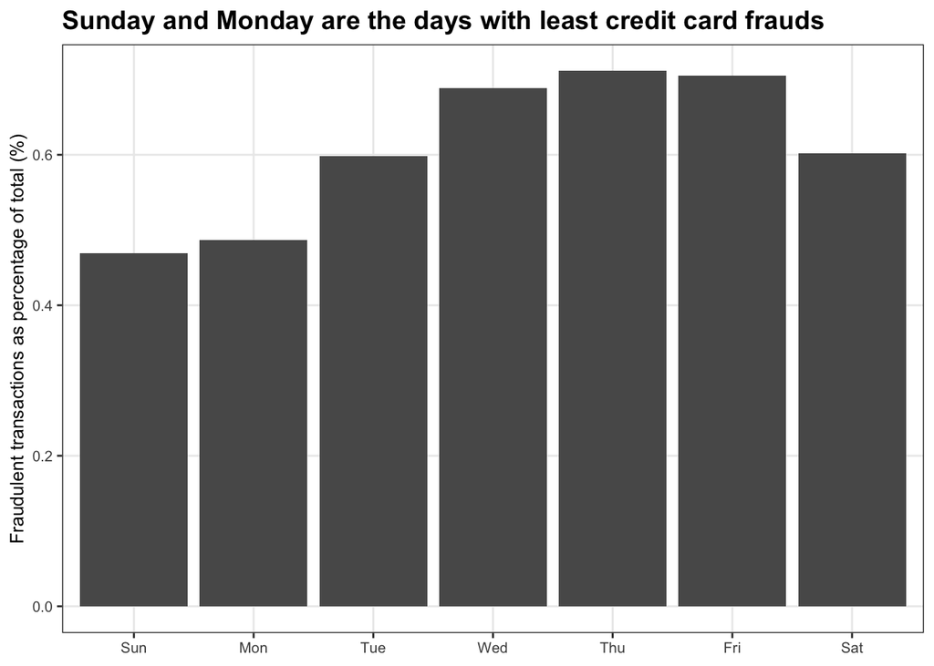

```r
card_fraud %>%
  group_by(wday) %>%
  summarise(
    n_fraud = sum(is_fraud == "1"), # The total # of fraudulent transactions
    total_n = n(), # The total # of f transactions
    percent_fraud = (n_fraud / total_n) * 100 # The percentage of fraudulent transactions
  ) %>%

  # Plotting our bar graph
  ggplot(aes(x =  wday, y = percent_fraud)) + # The days are already in order
    geom_bar(stat = "identity") +
    labs(
      title = "Sunday and Monday are the days with least credit card frauds",
      x = NULL,
      y = "Fraudulent transactions as percentage of total (%)"
    ) +
  theme(plot.title.position = "plot",
        plot.title = element_text(hjust = 0)) + # To move the title to the left
  theme_bw() +
  theme(
    plot.title     = element_text(size = 14, face = "bold"),
    axis.title.x   = element_text(size = 10),
    axis.title.y   = element_text(size = 10),
    axis.text      = element_text(size = 8),
    panel.grid.minor = element_blank()
  )
```

```r
# Convert to factor only (without order because step_dummy does not work well with ordered factors)
card_fraud$wday <- factor(card_fraud$wday, ordered = FALSE)
```

Just by LOOKING at the graph, we do see a difference in weekdays, specially if the transaction was made in Sunday and Monday. To test this assumption, we use a Chi-squared test. Our null hypotesis is that fraud is independent to weekday.

```r
# Chi-squared test for independence
chisq.test(table(card_fraud$wday, card_fraud$is_fraud))
```

```
##
##  Pearson's Chi-squared test
##
## data:  table(card_fraud$wday, card_fraud$is_fraud)
## X-squared = 105.5, df = 6, p-value < 2.2e-16
```

The evidence supporting the null variable (that is, the p-value) is way to small. So we REJECT the null hypotesis (meaning, fraud DOES depend on weekday).

**CONCLUSION:** Weekday IS an useful variable to predict fraud, **we will keep it in the model.**

### 1.5.6 Exploring month_name

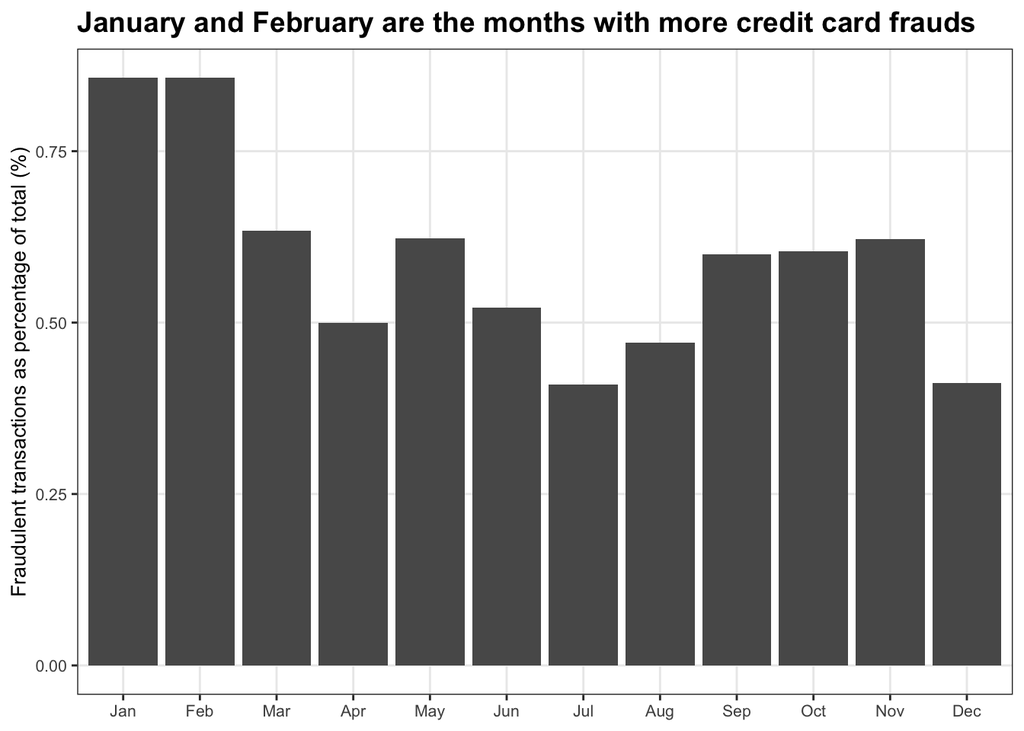

```r
card_fraud %>%
  group_by(month_name) %>%
  summarise(
    n_fraud = sum(is_fraud == "1"), # The total # of fraudulent transactions
    total_n = n(), # The total # of f transactions
    percent_fraud = (n_fraud / total_n) * 100 # The percentage of fraudulent transactions
  ) %>%

  # Plotting our bar graph
  ggplot(aes(x =  month_name, y = percent_fraud)) + # The days are already in order
    geom_bar(stat = "identity") +
    labs(
      title = "January and February are the months with more credit card frauds",
      x = NULL,
      y = "Fraudulent transactions as percentage of total (%)"
    ) +
  theme(plot.title.position = "plot",
        plot.title = element_text(hjust = 0)) + # To move the title to the left
  theme_bw() +
  theme(
    plot.title     = element_text(size = 14, face = "bold"),
    axis.title.x   = element_text(size = 10),
    axis.title.y   = element_text(size = 10),
    axis.text      = element_text(size = 8),
    panel.grid.minor = element_blank()
  )
```

Just by LOOKING at the graph, we do see a difference in months, specially if the transaction was made in January and February. To test this assumption, we use a Chi-squared test. Our null hypotesis is that fraud is independent to month.

```r
# Chi-squared test for independence
chisq.test(table(card_fraud$month_name, card_fraud$is_fraud))
```

```
##
##  Pearson's Chi-squared test
##
## data:  table(card_fraud$month_name, card_fraud$is_fraud)
## X-squared = 223.59, df = 11, p-value < 2.2e-16
```

The evidence supporting the null variable (that is, the p-value) is way to small. So we REJECT the null hypotesis (meaning, fraud DOES depend on month).

Finally, for it not to be necessary to create 11 dummy variables in the model (one for each month and excluding the base one), we will create a new variable called quarter and we will use this one as a variable in the model.

```r
card_fraud <- card_fraud %>%
  mutate(quarter = quarter(trans_date_trans_time, with_year = FALSE)) %>%
  mutate(quarter = factor(quarter))
```

**CONCLUSION:** Month name is an useful variable to predict fraud, so **we will keep it in our model** . However, instead of this one **we create a new variable (quarter) in order to have less categories**.

## 1.6 GEOSPACIAL

Geospacial variables are redundant to our analysis since we are already creating two new variables for distance, which are both computed based on our geospacial variables.

**CONCLUSION:** We **won’t include** ANY geospacial variables in the model.

## 1.7 DATES

### 1.7.1 Exploring dob

Makes no sense to explore this variable as we are already creating a new variable called age, which is the age of the card holder at the time of the transaction (computed as the difference between both dates - transaction date and dob).

**CONCLUSION:** Date of birth (dob) is **NOT an useful variable** to predict fraud.

# 2 DATE/TIMES:

### 2.0.1 Exploring trans_date_trans_time

It makes no sense to explore this variable as we already created new variables (hour, wday, month_name, age) based on this.

**CONCLUSION:** We **won’t include** this variable in the model.

# 3 NUMERICAL

### 3.0.1 Exploring year

Since we only have two years of data (2019 and 2020), there’s no need to create a graph for this one, by simply looking at the two fraud percentages we can conclude if the variable is useful or not.

```r
card_fraud %>%
  group_by(year) %>%
  summarise(
    n_fraud = sum(is_fraud == "1"), # The total # of fraudulent transactions
    total_n = n(), # The total # of f transactions
    percent_fraud = (n_fraud / total_n) * 100 # The percentage of fraudulent transactions
  )
```

```
## # A tibble: 2 × 4
##    year n_fraud total_n percent_fraud
##   <dbl>   <int>   <int>         <dbl>
## 1  2019    2721  478646         0.568
## 2  2020    1215  192382         0.632
```

As we can observe, the fraud percentage is very similar in both years, so we can conclude that year is not a useful variable to predict fraud.

**CONCLUSION:** Year is **NOT an useful variable** to predict fraud.

### 3.0.2 Exploring amt

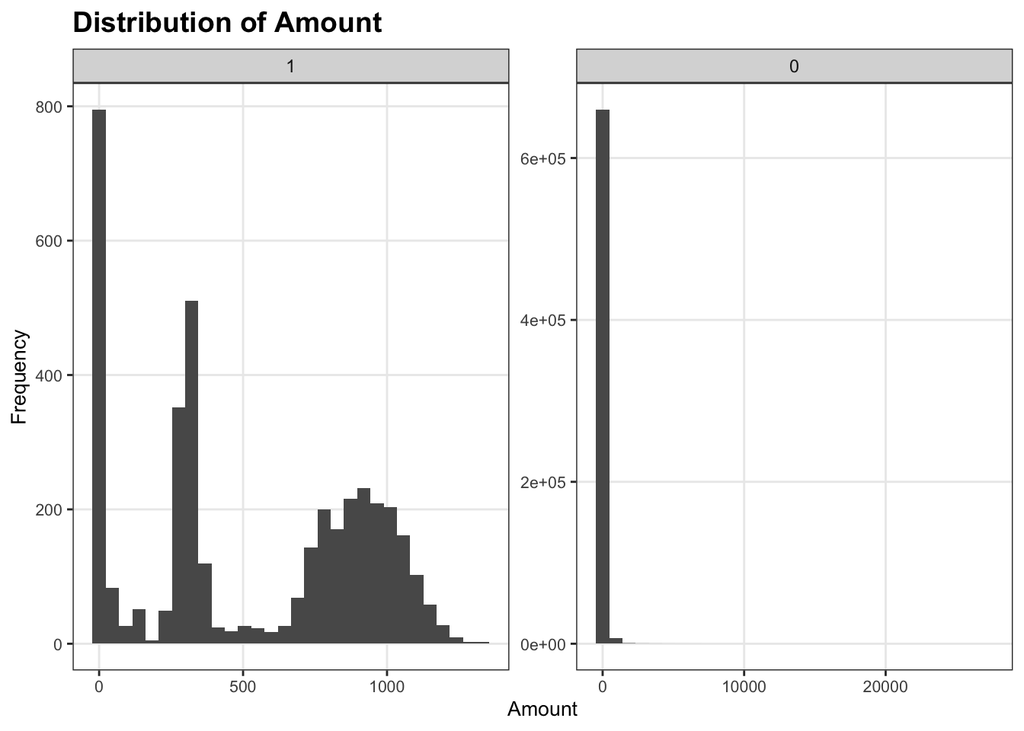

```r
# Plot amount as histogram
ggplot(card_fraud, aes(x = amt)) +
  geom_histogram(bins = 30) +
  labs(title = "Distribution of Amount", x = "Amount", y = "Frequency") +
  facet_wrap(~is_fraud, scales = "free") +
  theme_bw() +
  theme(
    plot.title     = element_text(size = 14, face = "bold"),
    axis.title.x   = element_text(size = 10),
    axis.title.y   = element_text(size = 10),
    axis.text      = element_text(size = 8),
    panel.grid.minor = element_blank()
  )
```

```r
card_fraud %>%
  group_by(is_fraud) %>%
  summarise(
    mean_amt = mean(amt, na.rm = TRUE),
    median_amt = median(amt, na.rm = TRUE),
    sd_amt = sd(amt, na.rm = TRUE),
    min_amt = min(amt, na.rm = TRUE),
    max_amt = max(amt, na.rm = TRUE)
  )
```

```
## # A tibble: 2 × 6
##   is_fraud mean_amt median_amt sd_amt min_amt max_amt
##   <fct>       <dbl>      <dbl>  <dbl>   <dbl>   <dbl>
## 1 1           527.       369.    391.    1.06   1334.
## 2 0            67.6       47.2   155.    1     27120.
```

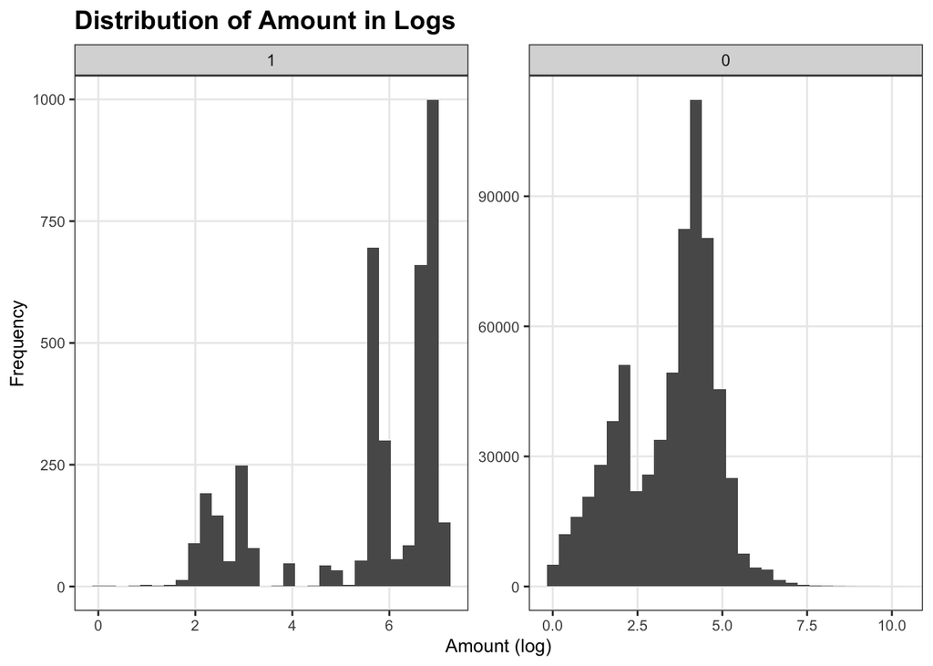

```r
# Convert amt to log scale for better visualization
card_fraud <- card_fraud %>%
  mutate(log_amt = log(amt))

ggplot(card_fraud, aes(x = log_amt)) +
  geom_histogram(bins = 30) +
  labs(title = "Distribution of Amount in Logs", x = "Amount (log)", y = "Frequency") +
  facet_wrap(~is_fraud, scales = "free") +
  theme_bw() +
  theme(
    plot.title     = element_text(size = 14, face = "bold"),
    axis.title.x   = element_text(size = 10),
    axis.title.y   = element_text(size = 10),
    axis.text      = element_text(size = 8),
    panel.grid.minor = element_blank()
  )
```

**CONCLUSION:** The amount variable is highly right-skewed, with most transactions being made at lower amounts and a few extreme outliers at high values. As it can be observed both in the histograms and in the summary table, fraudulent transactions have a much higher mean ($527 vs $67 in non-fraudulent ones), higher median ($369 vs $47) and higher standard deviation ($391 vs $155). However, non fraudulent transactions can achieve **much greater** values than fraudulent ones, as it can be observed in the histogram. The maximum amount registered for a fraudulent transaction is of $1,334; while for legitimate transaction this number rises up to $27,120.

This indicates that there IS a difference in transaction amounts depending on whether the transaction is fraudulent or not, making this variable important for fraud detection. Therefore, we decide to **include this variable in our model**.

### 3.0.3 Exploring city population

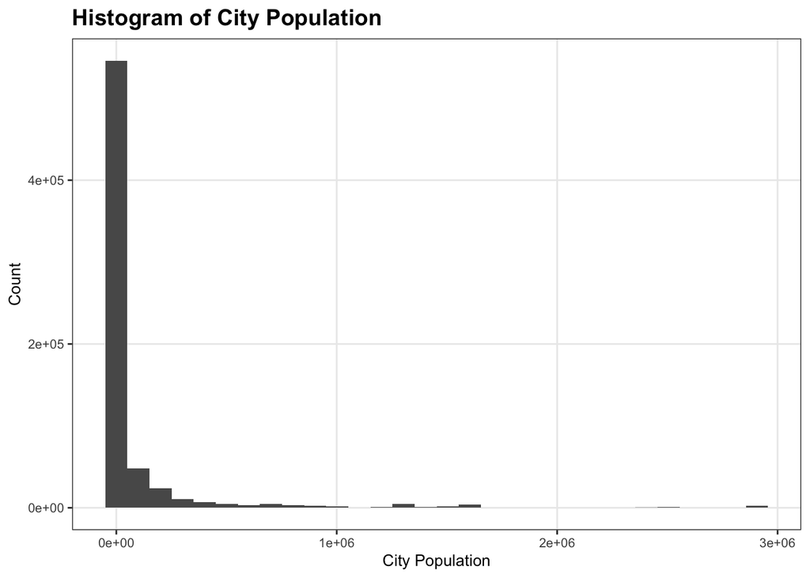

```r
# Initial histogram: There is a high dispersion
ggplot(card_fraud, aes(x = city_pop)) +
  geom_histogram(bins = 30) +
  labs(
    title = "Histogram of City Population",
    x = "City Population",
    y = "Count"
  ) +
  theme_bw() +
  theme(
    plot.title     = element_text(size = 14, face = "bold"),
    axis.title.x   = element_text(size = 10),
    axis.title.y   = element_text(size = 10),
    axis.text      = element_text(size = 8),
    panel.grid.minor = element_blank()
  )
```

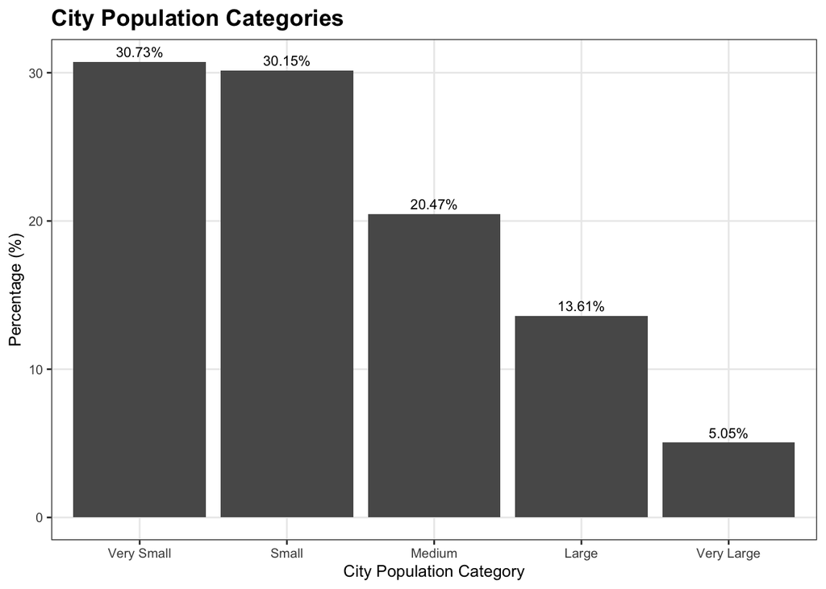

```r
# Transform the variable into categories
card_fraud = card_fraud %>%
  mutate(city_pop_cat = case_when(
    city_pop <= 1000 ~ "Very Small",
    city_pop <= 5000 ~ "Small",
    city_pop <= 50000 ~ "Medium",
    city_pop <= 500000 ~ "Large",
    TRUE ~ "Very Large"
  ))

# Count and percentage by category
card_fraud %>%
  count(city_pop_cat, sort = TRUE) %>%
  mutate(perc = round(n * 100 / sum(n), 2)) %>%
  ggplot(aes(x = reorder(city_pop_cat, -perc), y = perc)) +
  geom_col() +
  geom_text(aes(label = paste0(perc, "%")), vjust = -0.5, size = 3) +
  labs(
    title = "City Population Categories",
    x = "City Population Category",
    y = "Percentage (%)"
  ) +
  theme_bw() +
  theme(
    plot.title     = element_text(size = 14, face = "bold"),
    axis.title.x   = element_text(size = 10),
    axis.title.y   = element_text(size = 10),
    axis.text      = element_text(size = 8),
    panel.grid.minor = element_blank()
  )
```

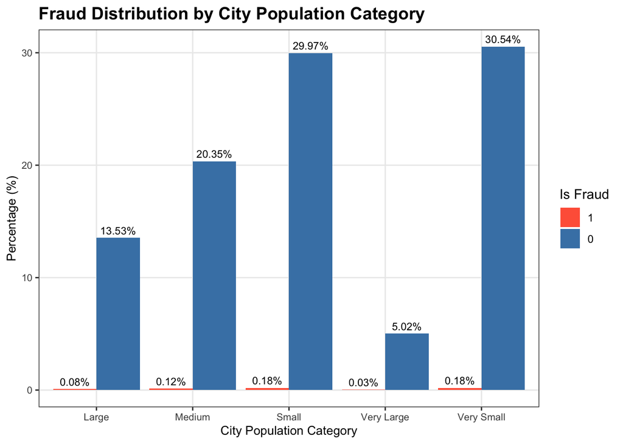

```r
# Barplot of is_fraud and city_pop_cat
card_fraud %>%
  group_by(city_pop_cat, is_fraud) %>%
  summarise(n = n(), .groups = "drop") %>% # To get rid of warnings
  mutate(perc = round(n * 100 / sum(n), 2)) %>%
  ggplot(aes(x = city_pop_cat, y = perc, fill = is_fraud)) +
  geom_col(position = "dodge") +
  geom_text(aes(label = paste0(perc, "%")), position = position_dodge(width = 0.9), vjust = -0.5, size = 3) +
  scale_fill_manual(values = c("0" = "steelblue", "1" = "tomato")) +  # Set colors here
  labs(
    title = "Fraud Distribution by City Population Category",
    x = "City Population Category",
    y = "Percentage (%)",
    fill = "Is Fraud"
  ) +
  theme_bw() +
  theme(
    plot.title     = element_text(size = 14, face = "bold"),
    axis.title.x   = element_text(size = 10),
    axis.title.y   = element_text(size = 10),
    axis.text      = element_text(size = 8),
    panel.grid.minor = element_blank()
  )
```

The city_pop variable was originally numeric, but its histogram showed a wide distribution with extreme outliers. To address this, we grouped it into five categories:

Very Small: 0–1,000 Small: 1,001–5,000 Medium: 5,001–50,000 Large: 50,001–500,000 Very Large: 500,001 and above

**Conclusion:** When comparing these categories with the is_fraud variable (last), we don’t observe any clear or significant differences in fraud occurrence across groups. Therefore, we decide to **drop this variable from the model**.

### 3.0.4 Exploring Hour

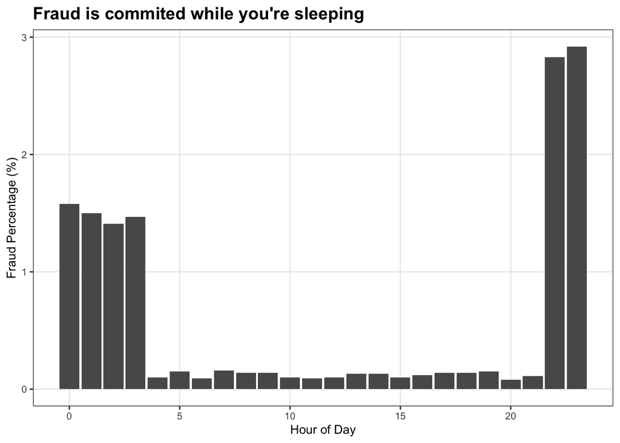

```r
card_fraud %>%
  group_by(hour, is_fraud) %>%
  count() %>%
  group_by(hour) %>%
  mutate(perc = round(n * 100 / sum(n), 2)) %>%
  filter(is_fraud == 1) %>%
  ggplot(aes(x = hour, y = perc)) +
  geom_col() +
  labs(
    title = "Fraud is commited while you're sleeping",
    x = "Hour of Day",
    y = "Fraud Percentage (%)"
  ) +
  theme_bw() +
  theme(
    plot.title     = element_text(size = 14, face = "bold"),
    axis.title.x   = element_text(size = 10),
    axis.title.y   = element_text(size = 10),
    axis.text      = element_text(size = 8),
    panel.grid.minor = element_blank()
  )
```

**CONCLUSION** We will **keep the variable** because it seems visually important for the classification. We will test it with the model.

### 3.0.5 Exploring age

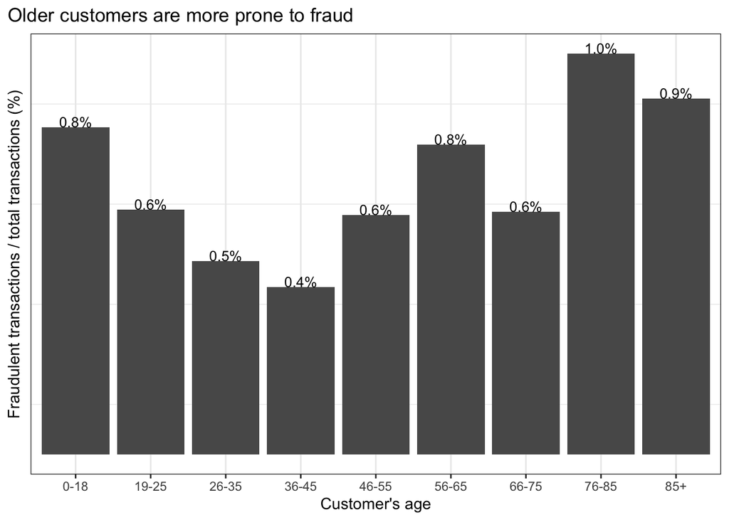

```r
# Create age group to simplify the analysis
card_fraud = card_fraud %>%
  mutate(age_group = case_when(
    age <= 18 ~ "0-18",
    age <= 25 ~ "19-25",
    age <= 35 ~ "26-35",
    age <= 45 ~ "36-45",
    age <= 55 ~ "46-55",
    age <= 65 ~ "56-65",
    age <= 75 ~ "66-75",
    age <= 85 ~ "76-85",
    TRUE ~ "85+"
  ))

card_fraud %>%
  group_by(age_group) %>%
  summarise(n_fraud = sum(is_fraud == 1), # The total # of fraudulent transactions
              total_n = n(), # The total # of f transactions
              percent_fraud = (n_fraud / total_n) * 100 # The percentage of fraudulent transactions
  ) %>%

  # Now we create a bar plot by age group...
  ggplot(aes(x = age_group, y = percent_fraud)) +
    geom_bar(stat = "identity") +
    geom_text(aes(label = sprintf("%.1f%%", percent_fraud)),
              vjust = -0.03, # To add the percentage as a label near the bar
              size = 3.5) +
    labs(
      title = "Older customers are more prone to fraud",
      x = "Customer's age",
     y = "Fraudulent transactions / total transactions (%)") +
    theme_bw() +
    theme(plot.title.position = "plot",
              axis.text.y = element_blank(), # I want to erase the y-axis as I already added labels
              axis.ticks.y = element_blank(),
              panel.grid.major.y = element_blank())
```

To test this, we use a Chi-squared test. Our null hypotesis is that fraud is independent to age.

```r
# Chi-squared test for independence
chisq.test(table(card_fraud$age_group, card_fraud$is_fraud))
```

```
##
##  Pearson's Chi-squared test
##
## data:  table(card_fraud$age_group, card_fraud$is_fraud)
## X-squared = 270.19, df = 8, p-value < 2.2e-16
```

The evidence supporting the null variable (that is, the p-value) is way to small. So we REJECT the null hypotesis (meaning, fraud DOES depend on age).

**CONCLUSION:** Age is an useful variable to predict fraud, so **we will keep it in our model** . However, instead of using age **we create a new variable (age_group) in order to have less categories**.

### 3.0.6 Exploring distance_miles and distance_km

The distance_miles and distance_km variables are numerical variables that represent the distance between the card holder’s location and the merchant’s location. We will keep only one of these variables, as they represent the same information in different units. We will keep distance_km.

```r
#---  Fraudulent transactions rate by distance_miles   ---#

# Percentile 99.5
quantile(card_fraud$distance_km, 0.995, na.rm = TRUE)
```

```
##    99.5%
## 135.2924
```

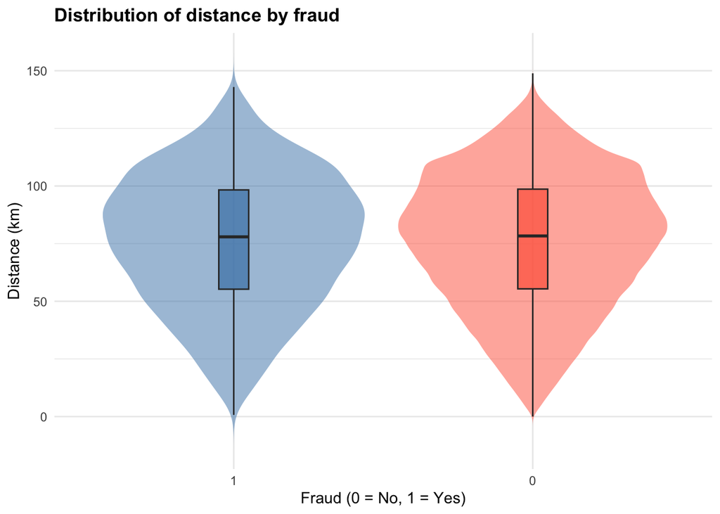

```r
# Plot distance by is_fraud
card_fraud %>%
  ggplot(aes(x = is_fraud, y = distance_km, fill = is_fraud)) +

  # Plot type
  geom_violin(trim = FALSE, alpha = 0.5, color = NA) +

  # Add boxplot in the center
  geom_boxplot(width = 0.1, outlier.size = 0.8, alpha = 0.7) +
  scale_fill_manual(values = c("steelblue", "tomato")) +
  labs(
    x = "Fraud (0 = No, 1 = Yes)",
    y = "Distance (km)",
    title = "Distribution of distance by fraud"
  ) +
  theme_minimal() +
  theme(
    legend.position = "none",
    plot.title = element_text(size = 13, face = "bold")
  ) +
  NULL
```

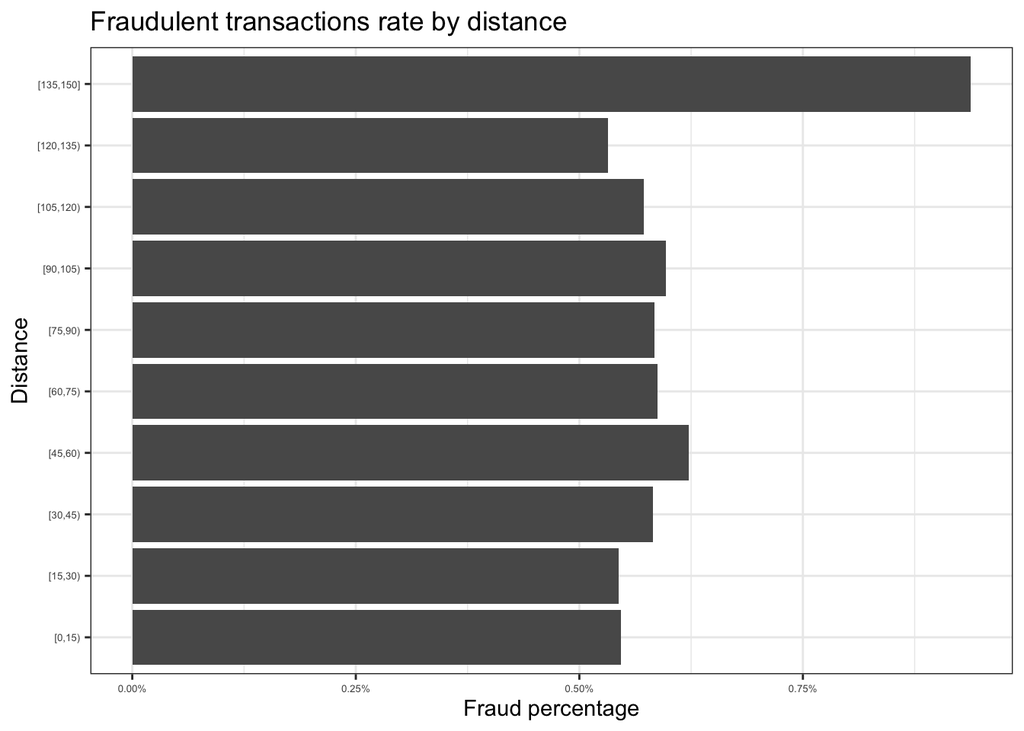

```r
card_fraud <- card_fraud %>%
  mutate(
    distance_bin = cut(
      distance_km,
      breaks = seq(0, max(distance_km, na.rm=TRUE) + 15, by = 15),
      right = FALSE,
      include.lowest = TRUE)
  )

# Fraudulent transaction by distance and state
card_fraud %>%
  group_by(distance_bin) %>%
  summarise(
    total = n(),
    frauds = sum(is_fraud == "1"),
    fraud_rate = frauds / total,
    .groups = "drop"
  ) %>%

  # Plot
  ggplot(aes(x = distance_bin, y = fraud_rate)) +

  # Plot type
  geom_col() +

  # Flip x and y axes
  coord_flip() +

  # Add facet wrap
  #facet_wrap(~state, ncol = 5) +

  # Add labels
  labs(
    x = "Distance",
    y = "Fraud percentage",
    title = "Fraudulent transactions rate by distance"
  ) +

  # Add theme
  theme_bw() +

  # Adjust y label to percentage
  scale_y_continuous(labels = scales::percent) +
  # Adjust x label size
  theme(axis.text.x = element_text(size = 5)) +
  theme(axis.text.y = element_text(size = 5)) +
  NULL
```

```r
# Chi-squared test for independence
chisq.test(table(card_fraud$distance_bin, card_fraud$is_fraud))
```

```
##
##  Pearson's Chi-squared test
##
## data:  table(card_fraud$distance_bin, card_fraud$is_fraud)
## X-squared = 13.204, df = 9, p-value = 0.1536
```

```r
# Convert distance_bin to a boolean factor variable
card_fraud <- card_fraud %>%
  mutate(
    is_distance_135_km = as.factor(ifelse(distance_km > 135, "1", "0"))
  )

# Chi-squared test for independence
chisq.test(table(card_fraud$is_distance_135_km, card_fraud$is_fraud))
```

```
##
##  Pearson's Chi-squared test with Yates' continuity correction
##
## data:  table(card_fraud$is_distance_135_km, card_fraud$is_fraud)
## X-squared = 7.1227, df = 1, p-value = 0.007612
```

Distance_km is NOT an useful variable to predict fraud, the distribution of distance_km appears similar for both fraudulent and non-fraudulent transactions, suggesting that distance alone may not be a strong predictor of fraud. However, we observe that transactions involving distances greater than 135 km —corresponding to the 99.5th percentile— can be flagged with a new binary variable. Notably, the fraud rate increases for these long-distance transactions; for instance, nearly 1% of transactions over 135 km are fraudulent. This pattern could indicate that such transactions carry a higher risk and may be useful for model features or rule-based alerts. Besides, the p-value of the chi-squared test for independence between is_distance_135_km and is_fraud is less than 0.05, indicating that there is a significant association between these two variables.

**CONCLUSION:** distance_miles is NOT an useful variable to predict fraud, however, **is_distance_135_km IS an useful variable to predict fraud**, therefore, we will keep that one in our model.

## 3.1 Which variables to keep in your model?

After doing our EDA, we will keep the following variables in our model:

### 3.1.1 STRING:

- category
- wday
- quarter
- age_group
- is_distance_135_km (derives from a numerical variable)

### 3.1.2 NUMERICAL:

- amt
- hour

```r
# Select the variables to keep in the model
card_fraud <- card_fraud %>%
  select(is_fraud, category, wday, quarter, age_group, is_distance_135_km,
         amt, hour)
```

## 3.2 Fit your workflows in smaller sample

We will work with a smaller sample of 10% of the values the original dataset to identify the best model, and once we have the best model we can use the full dataset to train- test our best model.

```r
# select a smaller subset
my_card_fraud <- card_fraud %>%
  # select a smaller subset, 10% of the entire dataframe
  slice_sample(prop = 0.10)
```

## 3.3 Split the data in training - testing

```r
# **Split the data**

set.seed(123)

data_split <- initial_split(my_card_fraud, # updated data
                           prop = 0.8,
                           strata = is_fraud)

card_fraud_train <- training(data_split)
card_fraud_test <- testing(data_split)
```

## 3.4 Cross Validation

We will work with 3 CV folds to quickly get an estimate for the best model.

```r
set.seed(123)
cv_folds <- vfold_cv(data = card_fraud_train,
                          v = 3,
                          strata = is_fraud)
cv_folds
```

```
## #  3-fold cross-validation using stratification
## # A tibble: 3 × 2
##   splits                id
##   <list>                <chr>
## 1 <split [35787/17894]> Fold1
## 2 <split [35787/17894]> Fold2
## 3 <split [35788/17893]> Fold3
```

## 3.5 Define a tidymodels `recipe`

```r
glimpse(card_fraud_train)
```

```
## Rows: 53,681
## Columns: 8
## $ is_fraud           <fct> 0, 0, 0, 0, 0, 0, 0, 0, 0, 0, 0, 0, 0, 0, 0, 0, 0, …
## $ category           <fct> gas_transport, travel, kids_pets, travel, shopping_…
## $ wday               <fct> Tue, Thu, Mon, Tue, Fri, Sat, Wed, Sun, Wed, Thu, F…
## $ quarter            <fct> 1, 3, 2, 2, 2, 2, 2, 3, 4, 1, 2, 2, 4, 1, 4, 4, 2, …
## $ age_group          <chr> "26-35", "36-45", "36-45", "26-35", "85+", "76-85",…
## $ is_distance_135_km <fct> 0, 0, 0, 0, 0, 0, 0, 0, 0, 0, 0, 0, 0, 0, 0, 0, 0, …
## $ amt                <dbl> 82.20, 2.70, 2.95, 467.51, 5.64, 44.78, 125.34, 4.1…
## $ hour               <int> 10, 18, 17, 19, 1, 19, 8, 18, 17, 10, 10, 10, 0, 11…
```

```r
fraud_rec <- recipe(is_fraud ~ ., data = card_fraud_train) %>%
  step_log(amt) %>% # Log transform amount
  step_novel(all_nominal(), -all_outcomes()) %>% # Use *before* `step_dummy()` so new level is dummified
  step_dummy(all_nominal(), -all_outcomes()) %>%
  step_zv(all_numeric(), -all_outcomes())  %>%
  step_normalize(amt,hour) %>%
  step_corr(all_predictors(), threshold = 0.75, method = "spearman")
```

Check the pre-processed dataframe

```r
prepped_data <-
  fraud_rec %>% # use the recipe object
  prep() %>% # perform the recipe on training data
  juice() # extract only the preprocessed dataframe

glimpse(prepped_data)
```

```
## Rows: 53,681
## Columns: 34
## $ amt                     <dbl> 0.6873564, -1.7682127, -1.7045549, 1.9369324, …
## $ hour                    <dbl> -0.4092186, 0.7618926, 0.6155037, 0.9082815, -…
## $ is_fraud                <fct> 0, 0, 0, 0, 0, 0, 0, 0, 0, 0, 0, 0, 0, 0, 0, 0…
## $ category_food_dining    <dbl> 0, 0, 0, 0, 0, 1, 0, 0, 0, 0, 0, 0, 0, 0, 0, 0…
## $ category_gas_transport  <dbl> 1, 0, 0, 0, 0, 0, 0, 0, 0, 0, 1, 0, 0, 1, 1, 0…
## $ category_grocery_net    <dbl> 0, 0, 0, 0, 0, 0, 0, 0, 0, 0, 0, 0, 0, 0, 0, 0…
## $ category_grocery_pos    <dbl> 0, 0, 0, 0, 0, 0, 1, 0, 0, 0, 0, 0, 0, 0, 0, 0…
## $ category_health_fitness <dbl> 0, 0, 0, 0, 0, 0, 0, 0, 0, 0, 0, 0, 0, 0, 0, 0…
## $ category_home           <dbl> 0, 0, 0, 0, 0, 0, 0, 0, 1, 0, 0, 0, 0, 0, 0, 0…
## $ category_kids_pets      <dbl> 0, 0, 1, 0, 0, 0, 0, 0, 0, 0, 0, 0, 0, 0, 0, 0…
## $ category_misc_net       <dbl> 0, 0, 0, 0, 0, 0, 0, 0, 0, 0, 0, 1, 0, 0, 0, 0…
## $ category_misc_pos       <dbl> 0, 0, 0, 0, 0, 0, 0, 0, 0, 0, 0, 0, 1, 0, 0, 0…
## $ category_personal_care  <dbl> 0, 0, 0, 0, 0, 0, 0, 0, 0, 0, 0, 0, 0, 0, 0, 0…
```

[output cut: 21 more lines]

## 3.6 Define various models

You should define the following classification models:

1. Logistic regression, using the `glm` engine
2. Decision tree, using the `C5.0` engine
3. Random Forest, using the `ranger` engine and setting `importance = "impurity"`)
4. A boosted tree using Extreme Gradient Boosting, and the `xgboost` engine
5. A k-nearest neighbours, using 4 nearest_neighbors and the `kknn` engine

```r
## Model Building

# 1. Pick a `model type`
# 2. set the `engine`
# 3. Set the `mode`: regression or classification

# Logistic regression
log_spec <-  logistic_reg() %>%  # model type
  set_engine(engine = "glm") %>%  # model engine
  set_mode("classification") # model mode

# Show your model specification
log_spec
```

```
## Logistic Regression Model Specification (classification)
##
## Computational engine: glm
```

```r
# Decision Tree
tree_spec <- decision_tree() %>%
  set_engine(engine = "C5.0") %>%
  set_mode("classification")

tree_spec
```

```
## Decision Tree Model Specification (classification)
##
## Computational engine: C5.0
```

```r
# Random Forest
rf_spec <-
  rand_forest() %>%
  set_engine("ranger", importance = "impurity") %>%
  set_mode("classification")


# Boosted tree (XGBoost)
xgb_spec <-
  boost_tree() %>%
  set_engine("xgboost") %>%
  set_mode("classification")

# K-nearest neighbour (k-NN)
knn_spec <-
  nearest_neighbor(neighbors = 4) %>% # we can adjust the number of neighbors
  set_engine("kknn") %>%
  set_mode("classification")
```

## 3.7 Bundle recipe and model with `workflows`

```r
## Bundle recipe and model with `workflows`

# Create a workflow object to bundle the recipe and model specification
log_wflow <- # new workflow object
 workflow() %>% # use workflow function
 add_recipe(fraud_rec) %>%   # use the new recipe
 add_model(log_spec)   # add your model spec

# show object
log_wflow
```

```
## ══ Workflow ════════════════════════════════════════════════════════════════════
## Preprocessor: Recipe
## Model: logistic_reg()
##
## ── Preprocessor ────────────────────────────────────────────────────────────────
## 6 Recipe Steps
##
## • step_log()
## • step_novel()
## • step_dummy()
## • step_zv()
## • step_normalize()
## • step_corr()
##
## ── Model ───────────────────────────────────────────────────────────────────────
## Logistic Regression Model Specification (classification)
##
## Computational engine: glm
```

```r
## A few more workflows

tree_wflow <-
 workflow() %>%
 add_recipe(fraud_rec) %>%
 add_model(tree_spec)

rf_wflow <-
 workflow() %>%
 add_recipe(fraud_rec) %>%
 add_model(rf_spec)

xgb_wflow <-
 workflow() %>%
 add_recipe(fraud_rec) %>%
 add_model(xgb_spec)

knn_wflow <-
 workflow() %>%
 add_recipe(fraud_rec) %>%
 add_model(knn_spec)
```

## 3.8 Fit models

```r
tic()
log_res <- log_wflow %>%
  fit_resamples(
    resamples = cv_folds,
    metrics = metric_set(
      recall, precision, f_meas, accuracy,
      kap, roc_auc, sens, spec),
    control = control_resamples(save_pred = TRUE))
time <- toc()
```

```
## 15.922 sec elapsed
```

```r
#Save the time of execution of each model
log_time <- list()
log_time$res <- time[[4]]


# Show average performance over all folds (note that we use log_res):
log_res %>%  collect_metrics(summarize = TRUE)
```

```
## # A tibble: 8 × 6
##   .metric   .estimator  mean     n   std_err .config
##   <chr>     <chr>      <dbl> <int>     <dbl> <chr>
## 1 accuracy  binary     0.995     3 0.000122  Preprocessor1_Model1
## 2 f_meas    binary     0.204     3 0.0320    Preprocessor1_Model1
## 3 kap       binary     0.203     3 0.0320    Preprocessor1_Model1
## 4 precision binary     0.740     3 0.0999    Preprocessor1_Model1
## 5 recall    binary     0.119     3 0.0196    Preprocessor1_Model1
## 6 roc_auc   binary     0.837     3 0.00794   Preprocessor1_Model1
## 7 sens      binary     0.119     3 0.0196    Preprocessor1_Model1
## 8 spec      binary     1.00      3 0.0000992 Preprocessor1_Model1
```

```r
# Show performance for every single fold:
log_res %>%  collect_metrics(summarize = FALSE)
```

```
## # A tibble: 24 × 5
##    id    .metric   .estimator .estimate .config
##    <chr> <chr>     <chr>          <dbl> <chr>
##  1 Fold1 recall    binary         0.08  Preprocessor1_Model1
##  2 Fold1 precision binary         0.615 Preprocessor1_Model1
##  3 Fold1 f_meas    binary         0.142 Preprocessor1_Model1
##  4 Fold1 accuracy  binary         0.995 Preprocessor1_Model1
##  5 Fold1 kap       binary         0.140 Preprocessor1_Model1
##  6 Fold1 sens      binary         0.08  Preprocessor1_Model1
##  7 Fold1 spec      binary         1.00  Preprocessor1_Model1
##  8 Fold1 roc_auc   binary         0.839 Preprocessor1_Model1
##  9 Fold2 recall    binary         0.143 Preprocessor1_Model1
## 10 Fold2 precision binary         0.938 Preprocessor1_Model1
## # ℹ 14 more rows
```

```r
## `collect_predictions()` and get confusion matrix{.smaller}

log_pred <- log_res %>% collect_predictions()

log_pred %>%  conf_mat(is_fraud, .pred_class)
```

```
##           Truth
## Prediction     1     0
##          1    37    13
##          0   273 53358
```

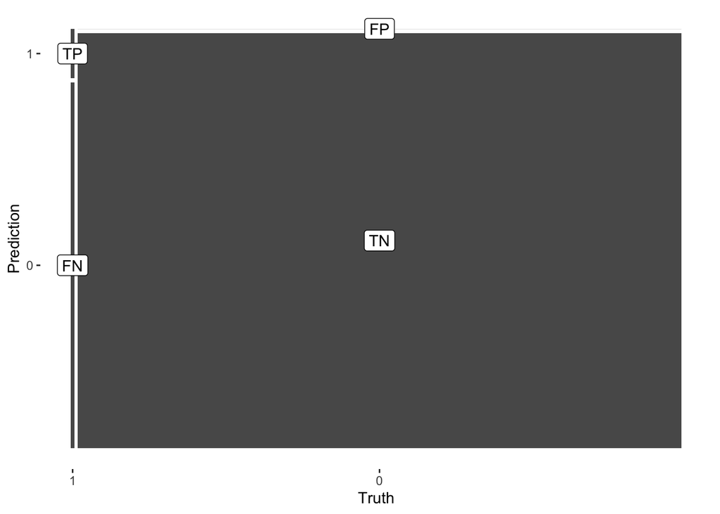

```r
log_pred %>%
  conf_mat(is_fraud, .pred_class) %>%
  autoplot(type = "mosaic") +
  geom_label(aes(
      x = (xmax + xmin) / 2,
      y = (ymax + ymin) / 2,
      label = c("TP", "FN", "FP", "TN")))
```

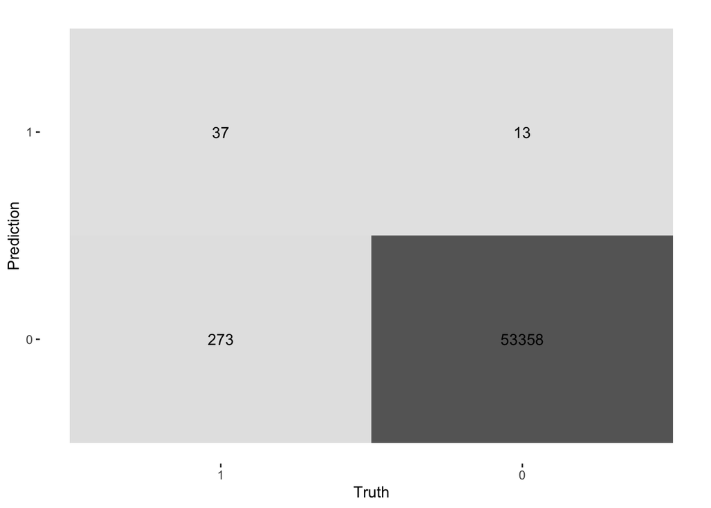

```r
log_pred %>%
  conf_mat(is_fraud, .pred_class) %>%
  autoplot(type = "heatmap")
```

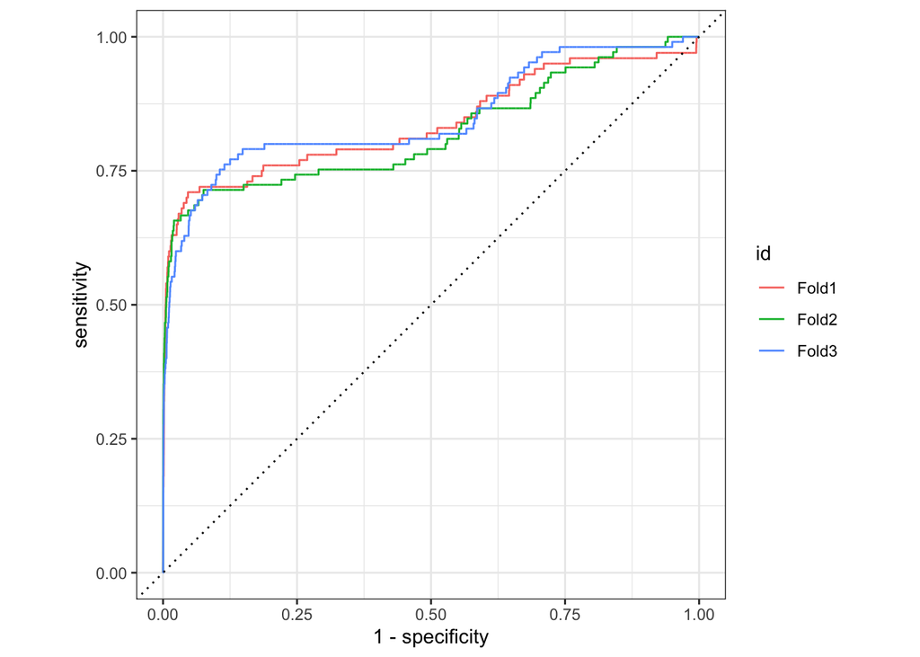

```r
## ROC Curve

log_pred %>%
  group_by(id) %>% # id contains our folds
  roc_curve(is_fraud, .pred_1) %>%
  autoplot()
```

```r
## Decision Tree results
tic()
tree_res <-
  tree_wflow %>%
  fit_resamples(
    resamples = cv_folds,
    metrics = metric_set(
      recall, precision, f_meas,
      accuracy, kap,
      roc_auc, sens, spec),
    control = control_resamples(save_pred = TRUE)
    )
time <- toc()
```

```
## 17.695 sec elapsed
```

```r
#Save the time of execution of each model
log_time$tree <- time[[4]]

tree_res %>%  collect_metrics(summarize = TRUE)
```

```
## # A tibble: 8 × 6
##   .metric   .estimator  mean     n   std_err .config
##   <chr>     <chr>      <dbl> <int>     <dbl> <chr>
## 1 accuracy  binary     0.997     3 0.0000492 Preprocessor1_Model1
## 2 f_meas    binary     0.671     3 0.0270    Preprocessor1_Model1
## 3 kap       binary     0.670     3 0.0270    Preprocessor1_Model1
## 4 precision binary     0.803     3 0.0470    Preprocessor1_Model1
## 5 recall    binary     0.590     3 0.0634    Preprocessor1_Model1
## 6 roc_auc   binary     0.881     3 0.0251    Preprocessor1_Model1
## 7 sens      binary     0.590     3 0.0634    Preprocessor1_Model1
## 8 spec      binary     0.999     3 0.000325  Preprocessor1_Model1
```

```r
## Random Forest
tic()
rf_res <-
  rf_wflow %>%
  fit_resamples(
    resamples = cv_folds,
    metrics = metric_set(
      recall, precision, f_meas,
      accuracy, kap,
      roc_auc, sens, spec),
    control = control_resamples(save_pred = TRUE)
    )
time <- toc()
```

```
## 33.689 sec elapsed
```

```r
#Save the time of execution of each model
log_time$rf <- time[[4]]

rf_res %>%  collect_metrics(summarize = TRUE)
```

```
## # A tibble: 8 × 6
##   .metric   .estimator  mean     n   std_err .config
##   <chr>     <chr>      <dbl> <int>     <dbl> <chr>
## 1 accuracy  binary     0.997     3 0.000159  Preprocessor1_Model1
## 2 f_meas    binary     0.602     3 0.0256    Preprocessor1_Model1
## 3 kap       binary     0.600     3 0.0257    Preprocessor1_Model1
## 4 precision binary     0.980     3 0.0204    Preprocessor1_Model1
## 5 recall    binary     0.436     3 0.0275    Preprocessor1_Model1
## 6 roc_auc   binary     0.989     3 0.000834  Preprocessor1_Model1
## 7 sens      binary     0.436     3 0.0275    Preprocessor1_Model1
## 8 spec      binary     1.00      3 0.0000562 Preprocessor1_Model1
```

```r
## Boosted tree - XGBoost
tic()
xgb_res <-
  xgb_wflow %>%
  fit_resamples(
    resamples = cv_folds,
    metrics = metric_set(
      recall, precision, f_meas,
      accuracy, kap,
      roc_auc, sens, spec),
    control = control_resamples(save_pred = TRUE)
    )
time <- toc()
```

```
## 14.001 sec elapsed
```

```r
#Save the time of execution of each model
log_time$xgb <- time[[4]]

xgb_res %>% collect_metrics(summarize = TRUE)
```

```
## # A tibble: 8 × 6
##   .metric   .estimator  mean     n  std_err .config
##   <chr>     <chr>      <dbl> <int>    <dbl> <chr>
## 1 accuracy  binary     0.997     3 0.000166 Preprocessor1_Model1
## 2 f_meas    binary     0.741     3 0.0159   Preprocessor1_Model1
## 3 kap       binary     0.740     3 0.0160   Preprocessor1_Model1
## 4 precision binary     0.845     3 0.0341   Preprocessor1_Model1
## 5 recall    binary     0.661     3 0.00556  Preprocessor1_Model1
## 6 roc_auc   binary     0.976     3 0.00495  Preprocessor1_Model1
## 7 sens      binary     0.661     3 0.00556  Preprocessor1_Model1
## 8 spec      binary     0.999     3 0.000166 Preprocessor1_Model1
```

```r
## K-nearest neighbour
tic()
knn_res <-
  knn_wflow %>%
  fit_resamples(
    resamples = cv_folds,
    metrics = metric_set(
      recall, precision, f_meas,
      accuracy, kap,
      roc_auc, sens, spec),
    control = control_resamples(save_pred = TRUE)
    )
time <- toc()
```

```
## 150.358 sec elapsed
```

```r
#Save the time of execution of each model
log_time$knn <- time[[4]]

knn_res %>% collect_metrics(summarize = TRUE)
```

```
## # A tibble: 8 × 6
##   .metric   .estimator  mean     n  std_err .config
##   <chr>     <chr>      <dbl> <int>    <dbl> <chr>
## 1 accuracy  binary     0.994     3 0.000178 Preprocessor1_Model1
## 2 f_meas    binary     0.168     3 0.00769  Preprocessor1_Model1
## 3 kap       binary     0.166     3 0.00780  Preprocessor1_Model1
## 4 precision binary     0.330     3 0.0269   Preprocessor1_Model1
## 5 recall    binary     0.113     3 0.00444  Preprocessor1_Model1
## 6 roc_auc   binary     0.604     3 0.00148  Preprocessor1_Model1
## 7 sens      binary     0.113     3 0.00444  Preprocessor1_Model1
## 8 spec      binary     0.999     3 0.000130 Preprocessor1_Model1
```

## 3.9 Compare models

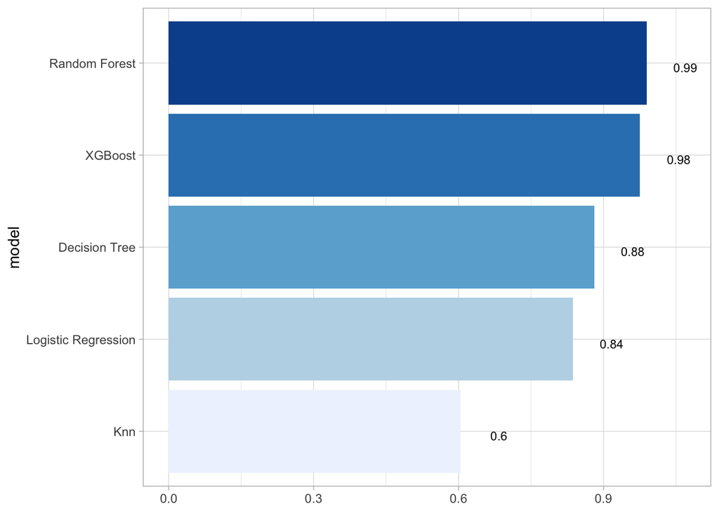

```r
## Model Comparison

log_metrics <-
  log_res %>%
  collect_metrics() %>% #summarize true
  # add the name of the model to every row
  mutate(model = "Logistic Regression",
         time = log_time$res)

# add more models here
tree_metrics <-
  tree_res %>%
  collect_metrics() %>%
  mutate(model = "Decision Tree")

rf_metrics <-
  rf_res %>%
  collect_metrics() %>%
  mutate(model = "Random Forest")

xgb_metrics <-
  xgb_res %>%
  collect_metrics() %>%
  mutate(model = "XGBoost")

knn_metrics <-
  knn_res %>%
  collect_metrics() %>%
  mutate(model = "Knn")

# create dataframe with all models
model_compare <- bind_rows(log_metrics,
                            tree_metrics,
                            rf_metrics,
                           xgb_metrics,
                           knn_metrics
                      ) %>%
  # get rid of 'sec elapsed' and turn it into a number
  mutate(time = str_sub(time, end = -13) %>%
           as.double()
         )


#Pivot wider to create barplot
  model_comp <- model_compare %>%
  select(model, .metric, mean, std_err) %>%
  pivot_wider(names_from = .metric, values_from = c(mean, std_err))

# show mean are under the curve (ROC-AUC) for every model
model_comp %>%
  arrange(mean_roc_auc) %>%
  mutate(model = fct_reorder(model, mean_roc_auc)) %>% # order results
  ggplot(aes(model, mean_roc_auc, fill=model)) +
  geom_col() +
  coord_flip() +
  scale_fill_brewer(palette = "Blues") +
   geom_text(
     size = 3,
     aes(label = round(mean_roc_auc, 2),
         y = mean_roc_auc + 0.08),
     vjust = 1
  )+
  theme_light()+
  theme(legend.position = "none")+
  labs(y = NULL)
```

## 3.10 Which metric to use

Since this is a classification problem, accuracy is not a good metric to use, as it can be misleading when the classes are imbalanced (like in this case, where more than 99% of the data is NOT fraudulent). This means, a model that predicts everything as non-fraud would still have a high accuracy. Therefore we chose to use roc_auc as our main metric. AUC (Area Under Curve) measures the overall ability of the model to rank a random positive higher than a random negative.

## 3.11 `last_fit()`

```r
## `last_fit()` on test set

# - `last_fit()`  fits a model to the whole training data and evaluates it on the test set.
# - provide the workflow object of the best model as well as the data split object (not the training data).

# Training data
xgb_res %>% collect_metrics(summarize = TRUE)
```

```
## # A tibble: 8 × 6
##   .metric   .estimator  mean     n  std_err .config
##   <chr>     <chr>      <dbl> <int>    <dbl> <chr>
## 1 accuracy  binary     0.997     3 0.000166 Preprocessor1_Model1
## 2 f_meas    binary     0.741     3 0.0159   Preprocessor1_Model1
## 3 kap       binary     0.740     3 0.0160   Preprocessor1_Model1
## 4 precision binary     0.845     3 0.0341   Preprocessor1_Model1
## 5 recall    binary     0.661     3 0.00556  Preprocessor1_Model1
## 6 roc_auc   binary     0.976     3 0.00495  Preprocessor1_Model1
## 7 sens      binary     0.661     3 0.00556  Preprocessor1_Model1
## 8 spec      binary     0.999     3 0.000166 Preprocessor1_Model1
```

```r
# Fitting data

last_fit_xgb <- last_fit(xgb_wflow,
                        split = data_split,
                        metrics = metric_set(
                          accuracy, f_meas, kap, precision,
                          recall, roc_auc, sens, spec))

last_fit_xgb %>% collect_metrics(summarize = TRUE)
```

```
## # A tibble: 8 × 4
##   .metric   .estimator .estimate .config
##   <chr>     <chr>          <dbl> <chr>
## 1 accuracy  binary         0.998 Preprocessor1_Model1
## 2 f_meas    binary         0.828 Preprocessor1_Model1
## 3 kap       binary         0.827 Preprocessor1_Model1
## 4 precision binary         0.883 Preprocessor1_Model1
## 5 recall    binary         0.779 Preprocessor1_Model1
## 6 sens      binary         0.779 Preprocessor1_Model1
## 7 spec      binary         0.999 Preprocessor1_Model1
## 8 roc_auc   binary         0.979 Preprocessor1_Model1
```

## 3.12 Get variable importance using `vip` package

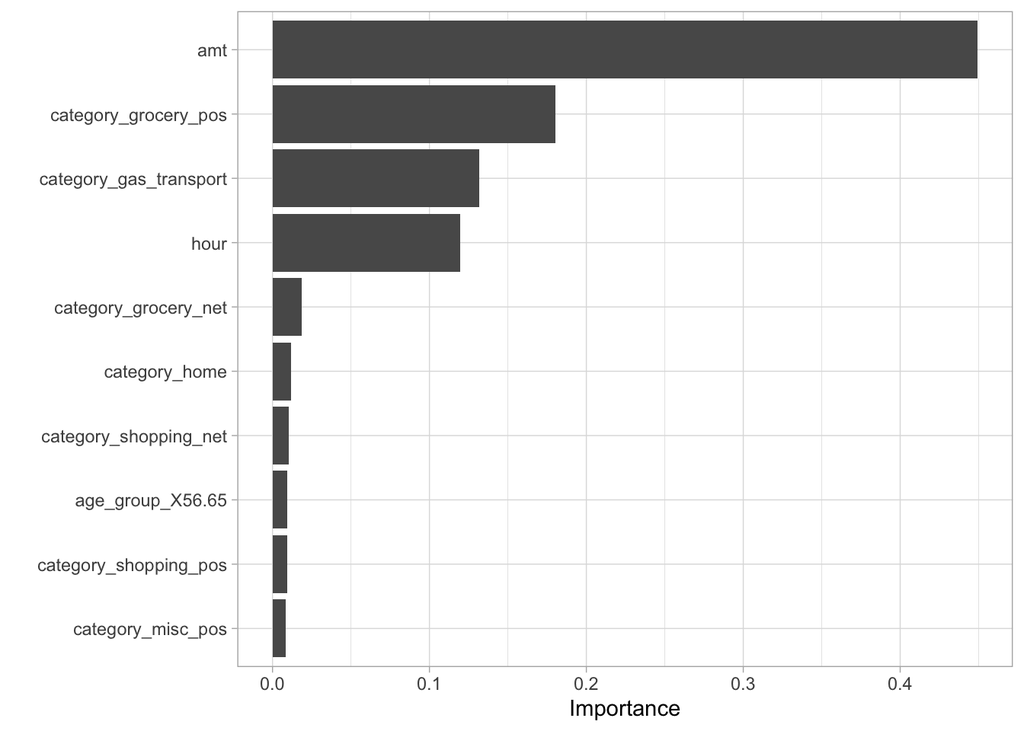

```r
## Variable importance using `{vip}` package
last_fit_xgb %>%
  pluck(".workflow", 1) %>%
  pull_workflow_fit() %>%
  vip(num_features = 10) +
  theme_light()
```

## 3.13 Plot Final Confusion matrix and ROC curve

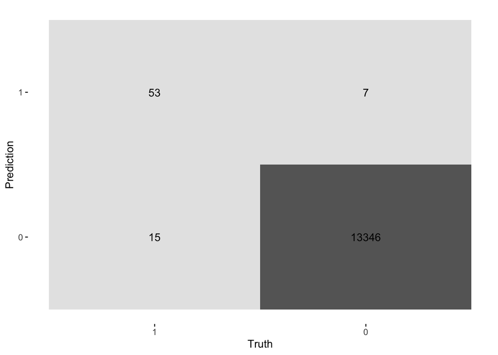

```r
## Final Confusion Matrix

last_fit_xgb %>%
  collect_predictions() %>%
  conf_mat(is_fraud, .pred_class) %>%
  autoplot(type = "heatmap")
```

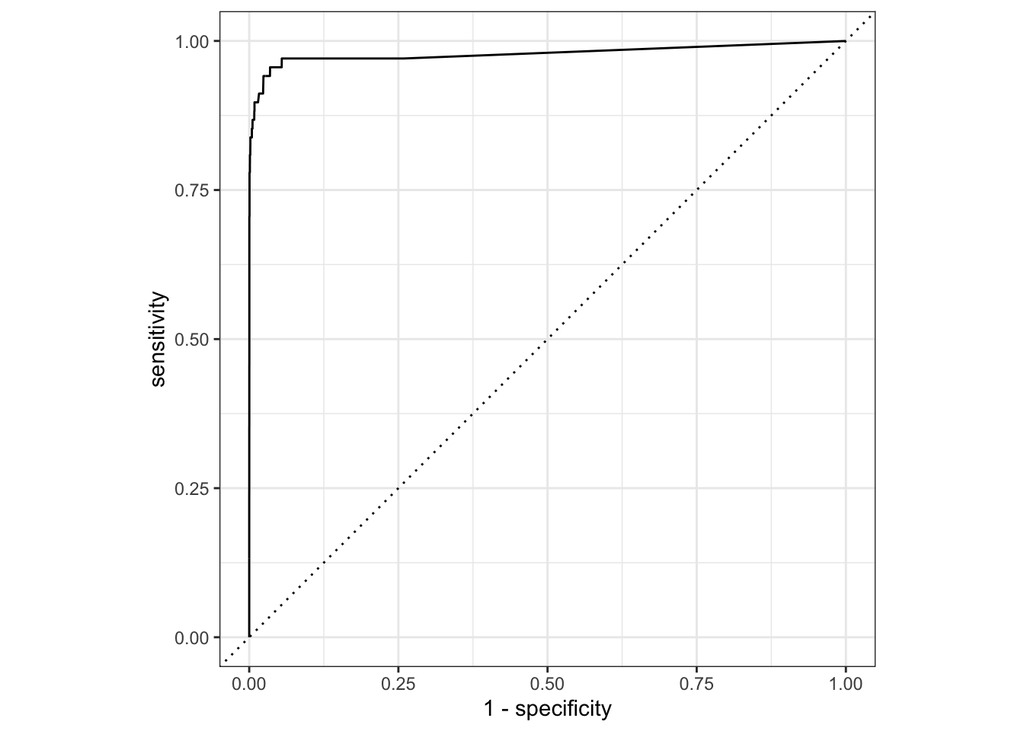

```r
## Final ROC curve
last_fit_xgb %>%
  collect_predictions() %>%
  roc_curve(is_fraud, .pred_1) %>%
  autoplot()
```

The ROC (Receiver Operating Characteristic) curve illustrates the trade-off between sensitivity and specificity across different threshold values. The curve rises sharply towards the top-left corner, indicating that the model is highly effective at distinguishing between fraudulent and non-fraudulent transactions. This is supported by a visually high AUC (Area Under the Curve), suggesting excellent overall discriminative ability. The ROC curve reinforces the model’s strong performance, especially in scenarios where ranking cases by risk is more important than the specific classification threshold.

## 3.14 Calculating the cost of fraud to the company

- How much money (in US$ terms) are fraudulent transactions costing the company? Generate a table that summarizes the total amount of legitimate and fraudulent transactions per year and calculate the % of fraudulent transactions, in US$ terms. Compare your model vs the naive classification that we do not have any fraudulent transactions.

```r
# 1. Fit the model and generate predictions for the entire data set
xgb_preds <-
  xgb_wflow %>%
  fit(data = card_fraud_train) %>%
  augment(new_data = card_fraud)

# 2. Display confusion matrix for reference
xgb_preds %>%
  conf_mat(truth = is_fraud, estimate = .pred_class)
```

```
##           Truth
## Prediction      1      0
##          1   2737    320
##          0   1199 666772
```

```r
# 3. Add actual transaction amounts and predicted classes to the dataset
cost <- xgb_preds %>%
  select(is_fraud, amt, pred = .pred_class)

# 4. Calculate cost outcomes for each transaction
cost <- cost %>%
  mutate(
    # False negatives: we thought they were not fraud, but they were
    false_negatives = ifelse(is_fraud == "1" & pred == "0", amt, 0),
    # False positives: we thought they were fraud, but they were not
    false_positives = ifelse(is_fraud == "0" & pred == "1", amt, 0),
    # True positives: we thought they were fraud, and they were
    true_positives  = ifelse(is_fraud == "1" & pred == "1", amt, 0),
    # True negatives: we thought they were ok, and they were
    true_negatives  = ifelse(is_fraud == "0" & pred == "0", amt, 0),
    # Naive case: if we classify everything as not fraud, we miss all fraud
    false_naives = ifelse(is_fraud == "1", amt, 0)
  )

# 5. Summarize total costs for the model vs naive baseline
cost_summary <- cost %>%
  summarise(across(starts_with(c("false","true", "amt")),
            ~ sum(.x, na.rm = TRUE)))

cost_summary
```

```
## # A tibble: 1 × 6
##   false_negatives false_positives false_naives true_positives true_negatives
##             <dbl>           <dbl>        <dbl>          <dbl>          <dbl>
## 1         412619.         244472.     2075089.       1662470.      44864343.
## # ℹ 1 more variable: amt <dbl>
```

```r
# 6. (Optional) Summarize overall fraud statistics
fraud_summary <- cost %>%
  summarise(
    Total_Transactions = sum(amt),
    Total_Fraud = sum(amt[is_fraud == "1"]),
    Percent_Fraud = 100 * sum(amt[is_fraud == "1"]) / sum(amt)
  )

print(fraud_summary)
```

```
## # A tibble: 1 × 3
##   Total_Transactions Total_Fraud Percent_Fraud
##                <dbl>       <dbl>         <dbl>
## 1          47183904.    2075089.          4.40
```

- If we use a naive classifier thinking that all transactions are legitimate and not fraudulent, the cost to the company is $2,075,089.
- With our best model, the total cost of false negatives, namely transactions our classifier thinks are legitimate but which turned out to be fraud, is $412,619.
- Our classifier also has some false positives, $244,472, namely flagging transactions as fraudulent, but which were legitimate. Assuming the card company makes around 2% for each transaction (source: https://startups.co.uk/payment-processing/credit-card-processing-fees/), the amount of money lost due to these false positives is $4,889.44
- The $ improvement over the naive policy is $1,657,580.